# Donadeo east entrance to Room ICE 8207

Photo-by-photo directions via the elevators to the eighth floor. Begin at the east entrance of the Donadeo Innovation Centre for Engineering and follow the numbered photos in order.

## 1Enter through the Donadeo east entrance

Find the glass entrance beside the Donadeo Innovation Centre for Engineering name and the Engineering crest. Go through these doors.

[figure not shown]

Photo 1 of 9

## 2Walk straight past the atrium stairs

Once inside, continue straight along the ground-floor passage, keeping the glass staircase on your right. Head toward the overhead Elevators sign.

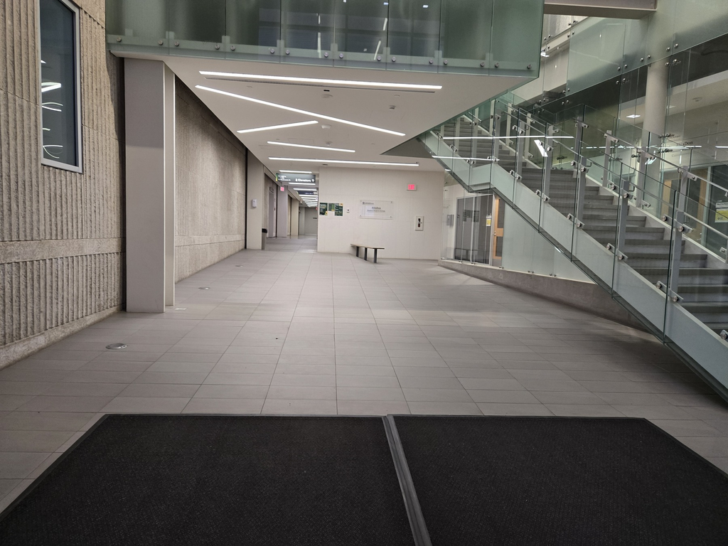

Photo 2 of 9

## 3Follow the Elevators sign

Continue straight under the overhead sign marked Elevators with an upward arrow. Follow the corridor ahead.

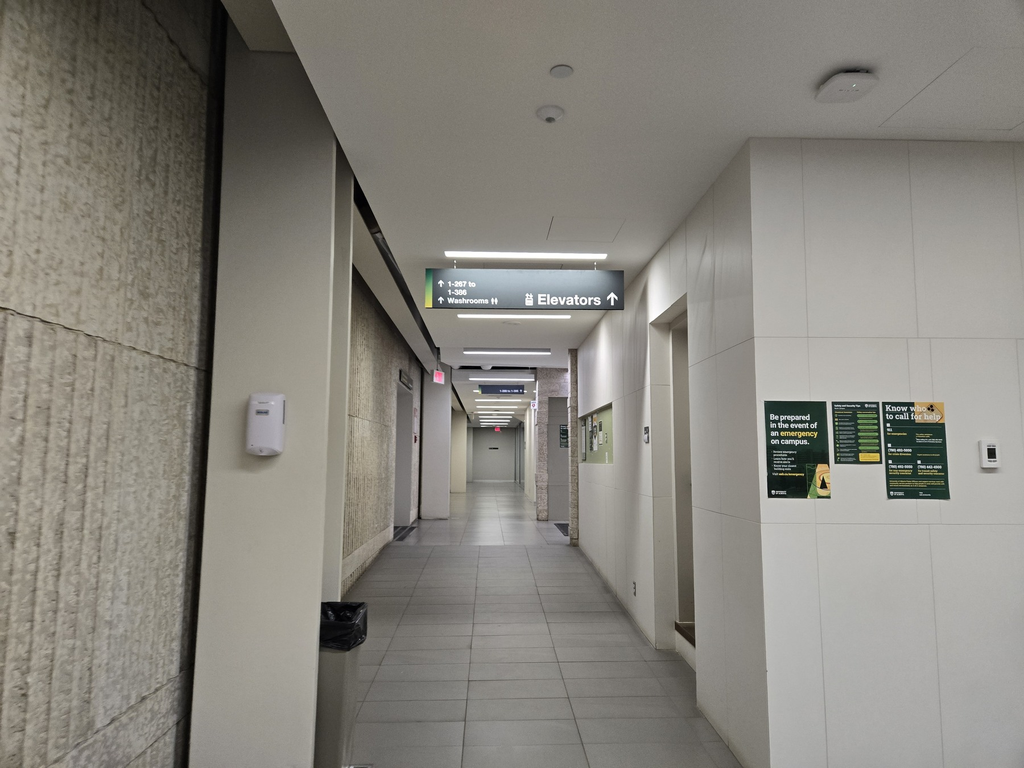

Photo 3 of 9

## 4Reach the elevator lobby

Enter the elevator lobby beside the building directory. Continue to the passenger elevators shown beyond the large service door.

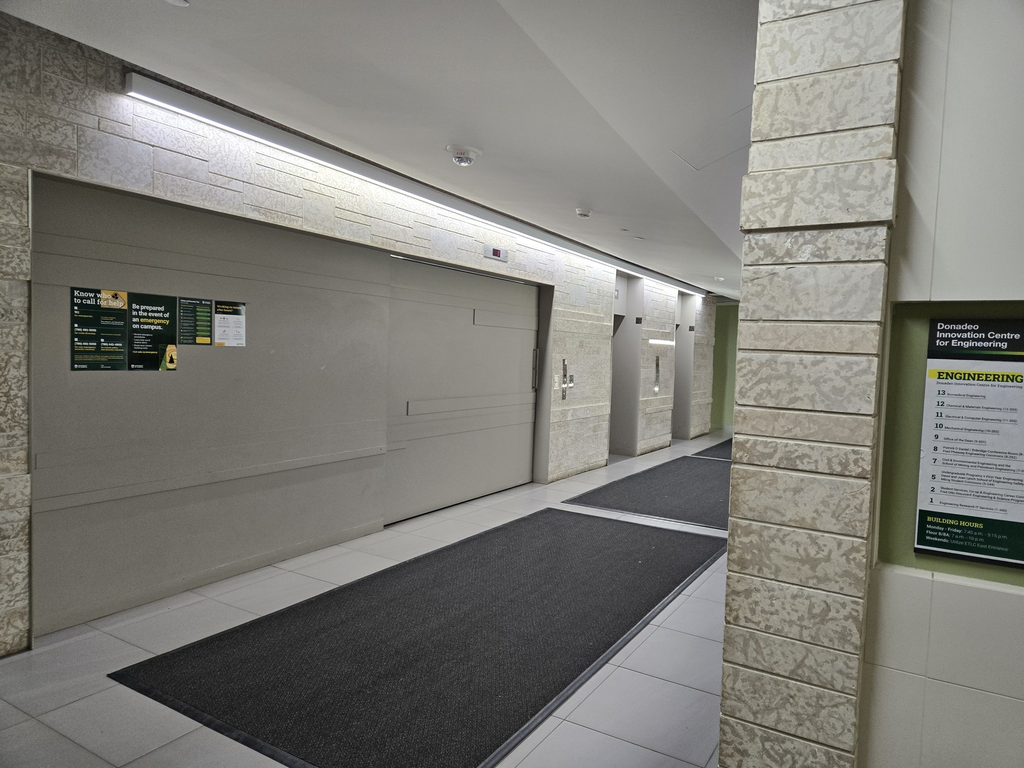

Photo 4 of 9

## 5Find the passenger elevators

The passenger elevators face one another in this lobby.

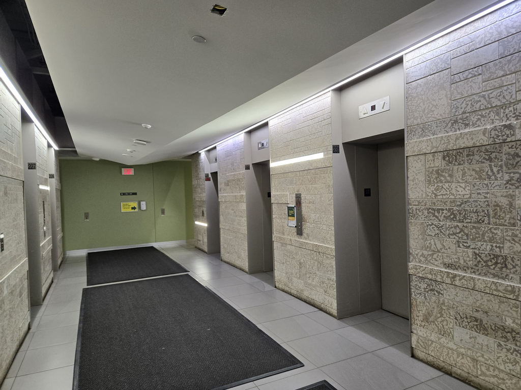

Photo 5 of 9

## 6Press the button for floor 8

Inside the elevator, press 8, as shown by the illuminated button. Take the elevator to the eighth floor and exit when it arrives.

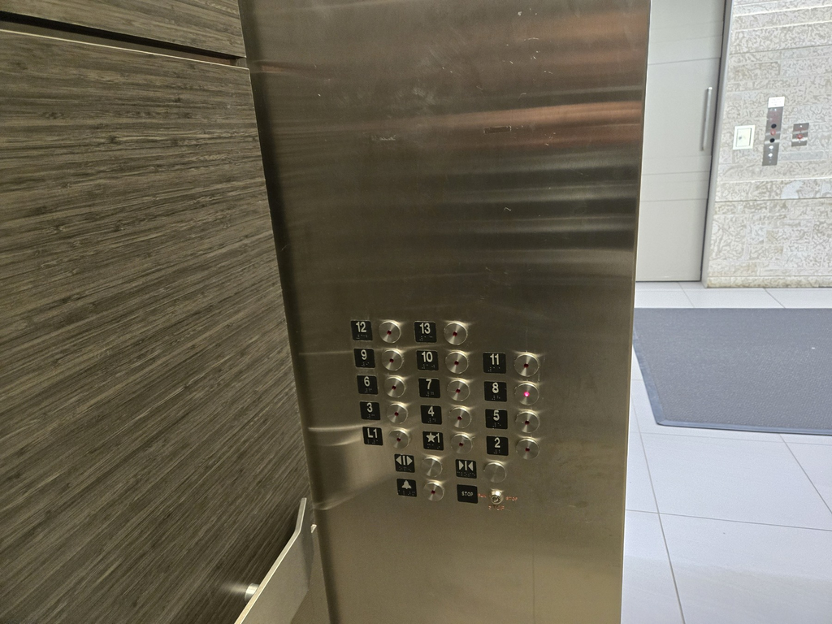

Photo 6 of 9

## 7Head toward the glass doors and turn left

On the eighth floor, go toward the glass doors shown here, then turn left. The wall sign points left toward rooms 8-207 to 8-246 and identifies the Engineering Conference Room 8-207.

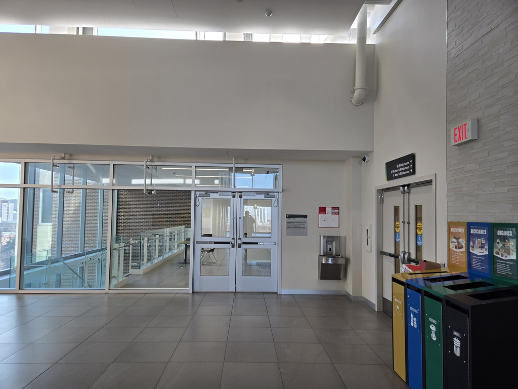

Photo 7 of 9

## 8Find Room 8-207

Look for the wooden double doors with the room plaque 8-207. The sign above reads Patrick D Daniel / Enbridge Engineering Conference Room. This is the workshop room.

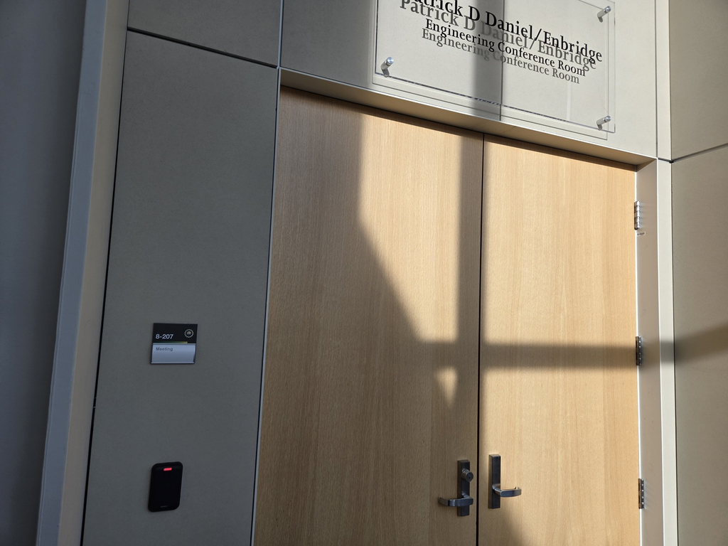

Photo 8 of 9

## 9The second entrance of Room 8207

Room 8207 also has a second entrance along the same corridor. Recognize it by the matching Patrick D Daniel / Enbridge Engineering Conference Room sign and the nearby blue seating.

[figure not shown]

Photo 9 of 9